# MLS - LBB5: Daily Exchange Rates per Euro

Taruma Sakti Megariansyah

2022-12-04

# 1 SETUP

```r
library(tidyverse)
library(ggplot2)
library(forcats)
library(caret)
library(forecast)
library(TTR)
library(fpp)
library(xts)
library(lubridate)
library(padr)
library(MLmetrics)
options(scipen=999)
knitr::opts_chunk$set(fig.align = "center")
```

```r
R.version
```

```
##                _
## platform       x86_64-w64-mingw32
## arch           x86_64
## os             mingw32
## crt            ucrt
## system         x86_64, mingw32
## status
## major          4
## minor          2.1
## year           2022
## month          06
## day            23
## svn rev        82513
## language       R
## version.string R version 4.2.1 (2022-06-23 ucrt)
## nickname       Funny-Looking Kid
```

LBB ini mendemonstrasikan pemodelan machine learning untuk data *time series*.

**Github**

Untuk file `.Rmd` atau `styles.css` bisa melihat github proyek ini di taruma/mls-lbb-5.

**Notasi $\text{matematika}$**

Untuk ribuan akan menggunakan pemisah koma ($,$), sedangkan pemisah untuk angka dibelakang koma (desimal/mantissa) menggunakan titik ($.$).

**Catatan**

Pada LBB ini untuk *piping* akan menggunakan *native piping* `|>` yang tersedia di `R 4.1+` untuk versi selain itu gunakan `%>%`.

# 2 Dataset

Dataset yang digunakan adalah data [*Daily Exchange Rates per Euro 1999-2022*](https://www.kaggle.com/datasets/lsind18/euro-exchange-daily-rates-19992020) yang diperoleh dari Kaggle (Data diunduh pada hari Senin, 28 November 2022). Dataset ini berisikan *Exchange Rate* (Nilai tukar) Euro/EUR (€) terhadap mata uang negara lain setiap harinya sejak tahun 1999. Berikut 6 baris pertama dataset.

```r
exchange <- read.csv("data/euro-daily-hist_1999_2022.csv")
exchange |> head()
```

|  | Period.Unit. | X.Australian.dollar.. | X.Bulgarian.lev.. | X.Brazilian.real.. | X.Canadian.dollar.. | X.Swiss.franc.. | X.Chinese.yuan.renminbi.. | X.Cypriot.pound.. | X.Czech.koruna.. | X.Danish.krone.. | X.Estonian.kroon.. | X.UK.pound.sterling.. | X.Greek.drachma.. | X.Hong.Kong.dollar.. | X.Croatian.kuna.. | X.Hungarian.forint.. | X.Indonesian.rupiah.. | X.Israeli.shekel.. | X.Indian.rupee.. | X.Iceland.krona.. | X.Japanese.yen.. | X.Korean.won.. | X.Lithuanian.litas.. | X.Latvian.lats.. | X.Maltese.lira.. | X.Mexican.peso.. | X.Malaysian.ringgit.. | X.Norwegian.krone.. | X.New.Zealand.dollar.. | … |
| --- | --- | --- | --- | --- | --- | --- | --- | --- | --- | --- | --- | --- | --- | --- | --- | --- | --- | --- | --- | --- | --- | --- | --- | --- | --- | --- | --- | --- | --- | --- |
| 1 | 2022-11-15 | 1.5415 | 1.9558 | 5.5480 | 1.3816 | 0.9790 | 7.3299 |  | 24.326 | 7.4388 |  | 0.87455 |  | 8.1430 | 7.5459 | 405.45 | 16164.78 | 3.5694 | 84.1304 | 149.9 | 144.84 | 1365.61 |  |  |  | 20.0795 | 4.7208 | 10.3570 | 1.6897 | … |
| 2 | 2022-11-14 | 1.5427 | 1.9558 | 5.4605 | 1.3706 | 0.9751 | 7.2906 |  | 24.289 | 7.4382 |  | 0.87513 |  | 8.0852 | 7.5465 | 407.28 | 16052.12 | 3.5410 | 83.7779 | 150.3 | 144.86 | 1369.32 |  |  |  | 20.0985 | 4.7429 | 10.3143 | 1.6957 | … |
| 3 | 2022-11-11 | 1.5459 | 1.9558 | 5.5147 | 1.3698 | 0.9844 | 7.3267 |  | 24.278 | 7.4384 |  | 0.87538 |  | 8.0758 | 7.5445 | 402.08 | 15979.45 | 3.5255 | 83.2253 | 148.7 | 143.89 | 1359.20 |  |  |  | 20.0239 | 4.7700 | 10.2635 | 1.7020 | … |
| 4 | 2022-11-10 | 1.5525 | 1.9558 | 5.2860 | 1.3467 | 0.9834 | 7.2184 |  | 24.361 | 7.4381 |  | 0.87298 |  | 7.8128 | 7.5427 | 400.95 | 15615.60 | 3.5453 | 81.3058 | 147.5 | 145.47 | 1373.96 |  |  |  | 19.4562 | 4.6789 | 10.3615 | 1.6984 | … |
| 5 | 2022-11-09 | 1.5538 | 1.9558 | 5.1947 | 1.3501 | 0.9880 | 7.2813 |  | 24.337 | 7.4382 |  | 0.87774 |  | 7.8801 | 7.5425 | 403.53 | 15717.07 | 3.5621 | 81.6575 | 146.7 | 146.82 | 1369.73 |  |  |  | 19.6554 | 4.7098 | 10.3220 | 1.7033 | … |
| 6 | 2022-11-08 | 1.5435 | 1.9558 | 5.2030 | 1.3489 | 0.9911 | 7.2495 |  | 24.326 | 7.4378 |  | 0.87378 |  | 7.8468 | 7.5390 | 400.75 | 15652.76 | 3.5436 | 81.5180 | 146.3 | 146.25 | 1377.94 |  |  |  | 19.4495 | 4.7346 | 10.2795 | 1.6860 | … |

Sebagai catatan, dataset diurutkan dari yang terbaru ke yang terlama. Sehingga, baris pertama merupakan data paling terbaru (2022) meski di halaman dataset dimulai dari 1999. Berikut 6 baris terakhir dataset `exchange`.

```r
exchange |> tail()
```

|  | Period.Unit. | X.Australian.dollar.. | X.Bulgarian.lev.. | X.Brazilian.real.. | X.Canadian.dollar.. | X.Swiss.franc.. | X.Chinese.yuan.renminbi.. | X.Cypriot.pound.. | X.Czech.koruna.. | X.Danish.krone.. | X.Estonian.kroon.. | X.UK.pound.sterling.. | X.Greek.drachma.. | X.Hong.Kong.dollar.. | X.Croatian.kuna.. | X.Hungarian.forint.. | X.Indonesian.rupiah.. | X.Israeli.shekel.. | X.Indian.rupee.. | X.Iceland.krona.. | X.Japanese.yen.. | X.Korean.won.. | X.Lithuanian.litas.. | X.Latvian.lats.. | X.Maltese.lira.. | X.Mexican.peso.. | X.Malaysian.ringgit.. | X.Norwegian.krone.. | X.New.Zealand.dollar.. | … |
| --- | --- | --- | --- | --- | --- | --- | --- | --- | --- | --- | --- | --- | --- | --- | --- | --- | --- | --- | --- | --- | --- | --- | --- | --- | --- | --- | --- | --- | --- | --- |
| 6172 | 1999-01-11 | 1.8134 |  |  | 1.7463 | 1.6104 |  | 0.58167 | 35.173 | 7.4433 | 15.6466 | 0.70440 | 323.40 | 8.9655 |  | 249.70 | 9255.61 |  |  | 80.55 | 126.33 | 1356.70 | 4.62960 | 0.6586 | 0.4405 | 11.4322 | 4.3970 | 8.5585 | 2.1257 | … |
| 6173 | 1999-01-08 | 1.8406 |  |  | 1.7643 | 1.6138 |  | 0.58187 | 34.938 | 7.4433 | 15.6466 | 0.70940 | 324.00 | 9.0302 |  | 250.15 | 9321.63 |  |  | 80.99 | 130.09 | 1366.73 | 4.66430 | 0.6654 | 0.4419 | 11.4414 | 4.4295 | 8.5900 | 2.1557 | … |
| 6174 | 1999-01-07 | 1.8474 |  |  | 1.7602 | 1.6165 |  | 0.58187 | 34.886 | 7.4431 | 15.6466 | 0.70585 | 324.40 | 9.0131 |  | 250.09 | 9218.77 |  |  | 81.06 | 129.43 | 1337.16 | 4.65480 | 0.6627 | 0.4413 | 11.5511 | 4.4203 | 8.6295 | 2.1531 | … |
| 6175 | 1999-01-06 | 1.8820 |  |  | 1.7711 | 1.6116 |  | 0.58200 | 34.850 | 7.4452 | 15.6466 | 0.70760 | 324.72 | 9.1010 |  | 250.67 | 9337.68 |  |  | 81.54 | 131.42 | 1359.54 | 4.69940 | 0.6649 | 0.4420 | 11.4705 | 4.4637 | 8.7335 | 2.1890 | … |
| 6176 | 1999-01-05 | 1.8944 |  |  | 1.7965 | 1.6123 |  | 0.58230 | 34.917 | 7.4495 | 15.6466 | 0.71220 | 324.70 | 9.1341 |  | 250.80 | 9314.51 |  |  | 81.53 | 130.96 | 1373.01 | 4.71740 | 0.6657 | 0.4432 | 11.5960 | 4.4805 | 8.7745 | 2.2011 | … |
| 6177 | 1999-01-04 | 1.9100 |  |  | 1.8004 | 1.6168 |  | 0.58231 | 35.107 | 7.4501 | 15.6466 | 0.71110 | 327.15 | 9.1332 |  | 251.48 | 9433.61 |  |  | 81.48 | 133.73 | 1398.59 | 4.71700 | 0.6668 | 0.4432 | 11.6446 | 4.4798 | 8.8550 | 2.2229 | … |

Berikut struktur dataset menggunakan `str()`.

```r
str(exchange)
```

```
## 'data.frame':    6177 obs. of  41 variables:
##  $ Period.Unit.             : chr  "2022-11-15" "2022-11-14" "2022-11-11" "2022-11-10" ...
##  $ X.Australian.dollar..    : chr  "1.5415" "1.5427" "1.5459" "1.5525" ...
##  $ X.Bulgarian.lev..        : chr  "1.9558" "1.9558" "1.9558" "1.9558" ...
##  $ X.Brazilian.real..       : chr  "5.5480" "5.4605" "5.5147" "5.2860" ...
##  $ X.Canadian.dollar..      : chr  "1.3816" "1.3706" "1.3698" "1.3467" ...
##  $ X.Swiss.franc..          : chr  "0.9790" "0.9751" "0.9844" "0.9834" ...
##  $ X.Chinese.yuan.renminbi..: chr  "7.3299" "7.2906" "7.3267" "7.2184" ...
##  $ X.Cypriot.pound..        : chr  "" "" "" "" ...
##  $ X.Czech.koruna..         : chr  "24.326" "24.289" "24.278" "24.361" ...
##  $ X.Danish.krone..         : chr  "7.4388" "7.4382" "7.4384" "7.4381" ...
##  $ X.Estonian.kroon..       : chr  "" "" "" "" ...
##  $ X.UK.pound.sterling..    : chr  "0.87455" "0.87513" "0.87538" "0.87298" ...
##  $ X.Greek.drachma..        : chr  "" "" "" "" ...
##  $ X.Hong.Kong.dollar..     : chr  "8.1430" "8.0852" "8.0758" "7.8128" ...
```

[output cut: 27 more lines]

Dari struktur diatas diketahui terdapat kolom/negara yang berupa `character`, yang seharusnya berupa angka/numeric. Oleh karena itu, dataset `exchange` harus diolah kembali sebelum dilakukan pemodelan. Sebagai catatan, dataset `exchange` memiliki $6,177$ baris/observasi dan $41$ kolom/variabel. Proses tersebut dilanjutkan ke **R1 - Pemrosesan Data**.

# 3 R1 - Pra-pemrosesan Data

Informasi struktur diatas menandakan banyak sekali yang harus diolah sebelum siap digunakan. Perubahan nama kolom dan tipe kolom merupakan hal yang cukup terlihat jelas dari kilasan dataset `exchange`. Sebelum memulai pra-pemrosesan data semua dataset yang digunakan pada tahap ini disimpan dalam objek `exchange_r1`.

```r
exchange_r1 <- exchange
exchange_r1 |> head()
```

|  | Period.Unit. | X.Australian.dollar.. | X.Bulgarian.lev.. | X.Brazilian.real.. | X.Canadian.dollar.. | X.Swiss.franc.. | X.Chinese.yuan.renminbi.. | X.Cypriot.pound.. | X.Czech.koruna.. | X.Danish.krone.. | X.Estonian.kroon.. | X.UK.pound.sterling.. | X.Greek.drachma.. | X.Hong.Kong.dollar.. | X.Croatian.kuna.. | X.Hungarian.forint.. | X.Indonesian.rupiah.. | X.Israeli.shekel.. | X.Indian.rupee.. | X.Iceland.krona.. | X.Japanese.yen.. | X.Korean.won.. | X.Lithuanian.litas.. | X.Latvian.lats.. | X.Maltese.lira.. | X.Mexican.peso.. | X.Malaysian.ringgit.. | X.Norwegian.krone.. | X.New.Zealand.dollar.. | … |
| --- | --- | --- | --- | --- | --- | --- | --- | --- | --- | --- | --- | --- | --- | --- | --- | --- | --- | --- | --- | --- | --- | --- | --- | --- | --- | --- | --- | --- | --- | --- |
| 1 | 2022-11-15 | 1.5415 | 1.9558 | 5.5480 | 1.3816 | 0.9790 | 7.3299 |  | 24.326 | 7.4388 |  | 0.87455 |  | 8.1430 | 7.5459 | 405.45 | 16164.78 | 3.5694 | 84.1304 | 149.9 | 144.84 | 1365.61 |  |  |  | 20.0795 | 4.7208 | 10.3570 | 1.6897 | … |
| 2 | 2022-11-14 | 1.5427 | 1.9558 | 5.4605 | 1.3706 | 0.9751 | 7.2906 |  | 24.289 | 7.4382 |  | 0.87513 |  | 8.0852 | 7.5465 | 407.28 | 16052.12 | 3.5410 | 83.7779 | 150.3 | 144.86 | 1369.32 |  |  |  | 20.0985 | 4.7429 | 10.3143 | 1.6957 | … |
| 3 | 2022-11-11 | 1.5459 | 1.9558 | 5.5147 | 1.3698 | 0.9844 | 7.3267 |  | 24.278 | 7.4384 |  | 0.87538 |  | 8.0758 | 7.5445 | 402.08 | 15979.45 | 3.5255 | 83.2253 | 148.7 | 143.89 | 1359.20 |  |  |  | 20.0239 | 4.7700 | 10.2635 | 1.7020 | … |
| 4 | 2022-11-10 | 1.5525 | 1.9558 | 5.2860 | 1.3467 | 0.9834 | 7.2184 |  | 24.361 | 7.4381 |  | 0.87298 |  | 7.8128 | 7.5427 | 400.95 | 15615.60 | 3.5453 | 81.3058 | 147.5 | 145.47 | 1373.96 |  |  |  | 19.4562 | 4.6789 | 10.3615 | 1.6984 | … |
| 5 | 2022-11-09 | 1.5538 | 1.9558 | 5.1947 | 1.3501 | 0.9880 | 7.2813 |  | 24.337 | 7.4382 |  | 0.87774 |  | 7.8801 | 7.5425 | 403.53 | 15717.07 | 3.5621 | 81.6575 | 146.7 | 146.82 | 1369.73 |  |  |  | 19.6554 | 4.7098 | 10.3220 | 1.7033 | … |
| 6 | 2022-11-08 | 1.5435 | 1.9558 | 5.2030 | 1.3489 | 0.9911 | 7.2495 |  | 24.326 | 7.4378 |  | 0.87378 |  | 7.8468 | 7.5390 | 400.75 | 15652.76 | 3.5436 | 81.5180 | 146.3 | 146.25 | 1377.94 |  |  |  | 19.4495 | 4.7346 | 10.2795 | 1.6860 | … |

## 3.1 Menamai Kolom

Nama kolom di `exchange` bisa berbeda ketika pembacaan dataset menggunakan `read_csv()`, tapi untuk dataset ini digunakan `read.csv()`. Nama kolom disimpan dalam variabel `name_columns`.

```r
name_columns <- colnames(exchange_r1)
name_columns
```

```
##  [1] "Period.Unit."              "X.Australian.dollar.."
##  [3] "X.Bulgarian.lev.."         "X.Brazilian.real.."
##  [5] "X.Canadian.dollar.."       "X.Swiss.franc.."
##  [7] "X.Chinese.yuan.renminbi.." "X.Cypriot.pound.."
##  [9] "X.Czech.koruna.."          "X.Danish.krone.."
## [11] "X.Estonian.kroon.."        "X.UK.pound.sterling.."
## [13] "X.Greek.drachma.."         "X.Hong.Kong.dollar.."
## [15] "X.Croatian.kuna.."         "X.Hungarian.forint.."
## [17] "X.Indonesian.rupiah.."     "X.Israeli.shekel.."
## [19] "X.Indian.rupee.."          "X.Iceland.krona.."
## [21] "X.Japanese.yen.."          "X.Korean.won.."
## [23] "X.Lithuanian.litas.."      "X.Latvian.lats.."
## [25] "X.Maltese.lira.."          "X.Mexican.peso.."
## [27] "X.Malaysian.ringgit.."     "X.Norwegian.krone.."
## [29] "X.New.Zealand.dollar.."    "X.Philippine.peso.."
## [31] "X.Polish.zloty.."          "X.Romanian.leu.."
## [33] "X.Russian.rouble.."        "X.Swedish.krona.."
## [35] "X.Singapore.dollar.."      "X.Slovenian.tolar.."
## [37] "X.Slovak.koruna.."         "X.Thai.baht.."
## [39] "X.Turkish.lira.."          "X.US.dollar.."
## [41] "X.South.African.rand.."
```

Strategi dalam membuat nama baru adalah seluruh nama kolom berhuruf kecil semua dengan pemisahnya menggunakan titik. Jadi karakter seperti `X.` dihilangkan, dan `..` dihapus juga. Proses tersebut dilakukan menggunakan `str_replace()` dan `str_to_lower()`. Nama baru kolom disimpan dalam variabel `newname_columns`. Berikut nama baru kolom.

```r
newname_columns <- name_columns |>
  str_replace("^X\\.", "") |>
  str_replace("\\.+$", "") |>
  str_to_lower()
newname_columns
```

```
##  [1] "period.unit"           "australian.dollar"     "bulgarian.lev"
##  [4] "brazilian.real"        "canadian.dollar"       "swiss.franc"
##  [7] "chinese.yuan.renminbi" "cypriot.pound"         "czech.koruna"
## [10] "danish.krone"          "estonian.kroon"        "uk.pound.sterling"
## [13] "greek.drachma"         "hong.kong.dollar"      "croatian.kuna"
## [16] "hungarian.forint"      "indonesian.rupiah"     "israeli.shekel"
## [19] "indian.rupee"          "iceland.krona"         "japanese.yen"
## [22] "korean.won"            "lithuanian.litas"      "latvian.lats"
## [25] "maltese.lira"          "mexican.peso"          "malaysian.ringgit"
## [28] "norwegian.krone"       "new.zealand.dollar"    "philippine.peso"
## [31] "polish.zloty"          "romanian.leu"          "russian.rouble"
## [34] "swedish.krona"         "singapore.dollar"      "slovenian.tolar"
## [37] "slovak.koruna"         "thai.baht"             "turkish.lira"
## [40] "us.dollar"             "south.african.rand"
```

Nama baru tersebut diterapkan ke dataset `exchange_r1` dan disimpan dalam objek baru bernama `exchange_r1_newname`.

```r
exchange_r1_newname <- exchange_r1 |>
  setNames(newname_columns)

exchange_r1_newname |> head()
```

|  | period.unit | australian.dollar | bulgarian.lev | brazilian.real | canadian.dollar | swiss.franc | chinese.yuan.renminbi | cypriot.pound | czech.koruna | danish.krone | estonian.kroon | uk.pound.sterling | greek.drachma | hong.kong.dollar | croatian.kuna | hungarian.forint | indonesian.rupiah | israeli.shekel | indian.rupee | iceland.krona | japanese.yen | korean.won | lithuanian.litas | latvian.lats | maltese.lira | mexican.peso | malaysian.ringgit | norwegian.krone | new.zealand.dollar | … |
| --- | --- | --- | --- | --- | --- | --- | --- | --- | --- | --- | --- | --- | --- | --- | --- | --- | --- | --- | --- | --- | --- | --- | --- | --- | --- | --- | --- | --- | --- | --- |
| 1 | 2022-11-15 | 1.5415 | 1.9558 | 5.5480 | 1.3816 | 0.9790 | 7.3299 |  | 24.326 | 7.4388 |  | 0.87455 |  | 8.1430 | 7.5459 | 405.45 | 16164.78 | 3.5694 | 84.1304 | 149.9 | 144.84 | 1365.61 |  |  |  | 20.0795 | 4.7208 | 10.3570 | 1.6897 | … |
| 2 | 2022-11-14 | 1.5427 | 1.9558 | 5.4605 | 1.3706 | 0.9751 | 7.2906 |  | 24.289 | 7.4382 |  | 0.87513 |  | 8.0852 | 7.5465 | 407.28 | 16052.12 | 3.5410 | 83.7779 | 150.3 | 144.86 | 1369.32 |  |  |  | 20.0985 | 4.7429 | 10.3143 | 1.6957 | … |
| 3 | 2022-11-11 | 1.5459 | 1.9558 | 5.5147 | 1.3698 | 0.9844 | 7.3267 |  | 24.278 | 7.4384 |  | 0.87538 |  | 8.0758 | 7.5445 | 402.08 | 15979.45 | 3.5255 | 83.2253 | 148.7 | 143.89 | 1359.20 |  |  |  | 20.0239 | 4.7700 | 10.2635 | 1.7020 | … |
| 4 | 2022-11-10 | 1.5525 | 1.9558 | 5.2860 | 1.3467 | 0.9834 | 7.2184 |  | 24.361 | 7.4381 |  | 0.87298 |  | 7.8128 | 7.5427 | 400.95 | 15615.60 | 3.5453 | 81.3058 | 147.5 | 145.47 | 1373.96 |  |  |  | 19.4562 | 4.6789 | 10.3615 | 1.6984 | … |
| 5 | 2022-11-09 | 1.5538 | 1.9558 | 5.1947 | 1.3501 | 0.9880 | 7.2813 |  | 24.337 | 7.4382 |  | 0.87774 |  | 7.8801 | 7.5425 | 403.53 | 15717.07 | 3.5621 | 81.6575 | 146.7 | 146.82 | 1369.73 |  |  |  | 19.6554 | 4.7098 | 10.3220 | 1.7033 | … |
| 6 | 2022-11-08 | 1.5435 | 1.9558 | 5.2030 | 1.3489 | 0.9911 | 7.2495 |  | 24.326 | 7.4378 |  | 0.87378 |  | 7.8468 | 7.5390 | 400.75 | 15652.76 | 3.5436 | 81.5180 | 146.3 | 146.25 | 1377.94 |  |  |  | 19.4495 | 4.7346 | 10.2795 | 1.6860 | … |

Dan berikut secara sekilas data `exchange_r1_newname`.

```r
exchange_r1_newname |>
  glimpse()
```

```
## Rows: 6,177
## Columns: 41
## $ period.unit           <chr> "2022-11-15", "2022-11-14", "2022-11-11", "2022-…
## $ australian.dollar     <chr> "1.5415", "1.5427", "1.5459", "1.5525", "1.5538"…
## $ bulgarian.lev         <chr> "1.9558", "1.9558", "1.9558", "1.9558", "1.9558"…
## $ brazilian.real        <chr> "5.5480", "5.4605", "5.5147", "5.2860", "5.1947"…
## $ canadian.dollar       <chr> "1.3816", "1.3706", "1.3698", "1.3467", "1.3501"…
## $ swiss.franc           <chr> "0.9790", "0.9751", "0.9844", "0.9834", "0.9880"…
## $ chinese.yuan.renminbi <chr> "7.3299", "7.2906", "7.3267", "7.2184", "7.2813"…
## $ cypriot.pound         <chr> "", "", "", "", "", "", "", "", "", "", "", "", …
## $ czech.koruna          <chr> "24.326", "24.289", "24.278", "24.361", "24.337"…
## $ danish.krone          <chr> "7.4388", "7.4382", "7.4384", "7.4381", "7.4382"…
## $ estonian.kroon        <chr> "", "", "", "", "", "", "", "", "", "", "", "", …
## $ uk.pound.sterling     <chr> "0.87455", "0.87513", "0.87538", "0.87298", "0.8…
## $ greek.drachma         <chr> "", "", "", "", "", "", "", "", "", "", "", "", …
```

[output cut: 28 more lines]

Setelah nama kolom sudah dibersihkan, bisa dilanjutkan untuk mengubah tipe data setiap kolomnya.

## 3.2 Mengubah Tipe Data Kolom

Melihat informasi sekilas mengenai dataset `exchange_r1_newname`. Terdapat dua jenis data yang berbeda di dataset. Kolom pertama yaitu `period.unit` berupa tanggal dengan format `YYYY-MM-DD`. Sedangkan kolom lainnya, merupakan kolom numerik.

### 3.2.1 Kolom Waktu

Kolom yang merupakan waktu yaitu `period.unit`. Berikut sekilas data pada kolom `periode.unit`.

```r
set.seed(41608481)
exchange_r1_newname$period.unit |> sample(size=10)
```

```
##  [1] "2021-12-30" "1999-10-13" "2013-07-15" "2001-12-14" "2019-07-25"
##  [6] "2015-02-16" "2009-04-30" "2007-05-10" "2012-03-09" "2004-10-05"
```

Setelah mengetahui format `YYYY-MM-DD`, kolom tersebut bisa dikonversi menggunakan *library* `lubridate` dengan fungsi `ymd()`. Hasil perubahan tersebut disimpan dalam bentuk objek baru bernama `exchange_r1_date`. Berikut beberapa baris pertamanya.

```r
exchange_r1_date <- exchange_r1_newname |>
  mutate(period.unit = ymd(period.unit))
exchange_r1_date |> head()
```

|  | period.unit | australian.dollar | bulgarian.lev | brazilian.real | canadian.dollar | swiss.franc | chinese.yuan.renminbi | cypriot.pound | czech.koruna | danish.krone | estonian.kroon | uk.pound.sterling | greek.drachma | hong.kong.dollar | croatian.kuna | hungarian.forint | indonesian.rupiah | israeli.shekel | indian.rupee | iceland.krona | japanese.yen | korean.won | lithuanian.litas | latvian.lats | maltese.lira | mexican.peso | malaysian.ringgit | norwegian.krone | new.zealand.dollar | … |
| --- | --- | --- | --- | --- | --- | --- | --- | --- | --- | --- | --- | --- | --- | --- | --- | --- | --- | --- | --- | --- | --- | --- | --- | --- | --- | --- | --- | --- | --- | --- |
| 1 | 2022-11-15 | 1.5415 | 1.9558 | 5.5480 | 1.3816 | 0.9790 | 7.3299 |  | 24.326 | 7.4388 |  | 0.87455 |  | 8.1430 | 7.5459 | 405.45 | 16164.78 | 3.5694 | 84.1304 | 149.9 | 144.84 | 1365.61 |  |  |  | 20.0795 | 4.7208 | 10.3570 | 1.6897 | … |
| 2 | 2022-11-14 | 1.5427 | 1.9558 | 5.4605 | 1.3706 | 0.9751 | 7.2906 |  | 24.289 | 7.4382 |  | 0.87513 |  | 8.0852 | 7.5465 | 407.28 | 16052.12 | 3.5410 | 83.7779 | 150.3 | 144.86 | 1369.32 |  |  |  | 20.0985 | 4.7429 | 10.3143 | 1.6957 | … |
| 3 | 2022-11-11 | 1.5459 | 1.9558 | 5.5147 | 1.3698 | 0.9844 | 7.3267 |  | 24.278 | 7.4384 |  | 0.87538 |  | 8.0758 | 7.5445 | 402.08 | 15979.45 | 3.5255 | 83.2253 | 148.7 | 143.89 | 1359.20 |  |  |  | 20.0239 | 4.7700 | 10.2635 | 1.7020 | … |
| 4 | 2022-11-10 | 1.5525 | 1.9558 | 5.2860 | 1.3467 | 0.9834 | 7.2184 |  | 24.361 | 7.4381 |  | 0.87298 |  | 7.8128 | 7.5427 | 400.95 | 15615.60 | 3.5453 | 81.3058 | 147.5 | 145.47 | 1373.96 |  |  |  | 19.4562 | 4.6789 | 10.3615 | 1.6984 | … |
| 5 | 2022-11-09 | 1.5538 | 1.9558 | 5.1947 | 1.3501 | 0.9880 | 7.2813 |  | 24.337 | 7.4382 |  | 0.87774 |  | 7.8801 | 7.5425 | 403.53 | 15717.07 | 3.5621 | 81.6575 | 146.7 | 146.82 | 1369.73 |  |  |  | 19.6554 | 4.7098 | 10.3220 | 1.7033 | … |
| 6 | 2022-11-08 | 1.5435 | 1.9558 | 5.2030 | 1.3489 | 0.9911 | 7.2495 |  | 24.326 | 7.4378 |  | 0.87378 |  | 7.8468 | 7.5390 | 400.75 | 15652.76 | 3.5436 | 81.5180 | 146.3 | 146.25 | 1377.94 |  |  |  | 19.4495 | 4.7346 | 10.2795 | 1.6860 | … |

Untuk memudahkan membaca, dataset diurutkan berdasarkan tanggal.

```r
exchange_r1_date <- exchange_r1_date |>
  arrange(period.unit)
exchange_r1_date |> head()
```

|  | period.unit | australian.dollar | bulgarian.lev | brazilian.real | canadian.dollar | swiss.franc | chinese.yuan.renminbi | cypriot.pound | czech.koruna | danish.krone | estonian.kroon | uk.pound.sterling | greek.drachma | hong.kong.dollar | croatian.kuna | hungarian.forint | indonesian.rupiah | israeli.shekel | indian.rupee | iceland.krona | japanese.yen | korean.won | lithuanian.litas | latvian.lats | maltese.lira | mexican.peso | malaysian.ringgit | norwegian.krone | new.zealand.dollar | … |
| --- | --- | --- | --- | --- | --- | --- | --- | --- | --- | --- | --- | --- | --- | --- | --- | --- | --- | --- | --- | --- | --- | --- | --- | --- | --- | --- | --- | --- | --- | --- |
| 1 | 1999-01-04 | 1.9100 |  |  | 1.8004 | 1.6168 |  | 0.58231 | 35.107 | 7.4501 | 15.6466 | 0.71110 | 327.15 | 9.1332 |  | 251.48 | 9433.61 |  |  | 81.48 | 133.73 | 1398.59 | 4.71700 | 0.6668 | 0.4432 | 11.6446 | 4.4798 | 8.8550 | 2.2229 | … |
| 2 | 1999-01-05 | 1.8944 |  |  | 1.7965 | 1.6123 |  | 0.58230 | 34.917 | 7.4495 | 15.6466 | 0.71220 | 324.70 | 9.1341 |  | 250.80 | 9314.51 |  |  | 81.53 | 130.96 | 1373.01 | 4.71740 | 0.6657 | 0.4432 | 11.5960 | 4.4805 | 8.7745 | 2.2011 | … |
| 3 | 1999-01-06 | 1.8820 |  |  | 1.7711 | 1.6116 |  | 0.58200 | 34.850 | 7.4452 | 15.6466 | 0.70760 | 324.72 | 9.1010 |  | 250.67 | 9337.68 |  |  | 81.54 | 131.42 | 1359.54 | 4.69940 | 0.6649 | 0.4420 | 11.4705 | 4.4637 | 8.7335 | 2.1890 | … |
| 4 | 1999-01-07 | 1.8474 |  |  | 1.7602 | 1.6165 |  | 0.58187 | 34.886 | 7.4431 | 15.6466 | 0.70585 | 324.40 | 9.0131 |  | 250.09 | 9218.77 |  |  | 81.06 | 129.43 | 1337.16 | 4.65480 | 0.6627 | 0.4413 | 11.5511 | 4.4203 | 8.6295 | 2.1531 | … |
| 5 | 1999-01-08 | 1.8406 |  |  | 1.7643 | 1.6138 |  | 0.58187 | 34.938 | 7.4433 | 15.6466 | 0.70940 | 324.00 | 9.0302 |  | 250.15 | 9321.63 |  |  | 80.99 | 130.09 | 1366.73 | 4.66430 | 0.6654 | 0.4419 | 11.4414 | 4.4295 | 8.5900 | 2.1557 | … |
| 6 | 1999-01-11 | 1.8134 |  |  | 1.7463 | 1.6104 |  | 0.58167 | 35.173 | 7.4433 | 15.6466 | 0.70440 | 323.40 | 8.9655 |  | 249.70 | 9255.61 |  |  | 80.55 | 126.33 | 1356.70 | 4.62960 | 0.6586 | 0.4405 | 11.4322 | 4.3970 | 8.5585 | 2.1257 | … |

Kita lihat *range* waktu yang digunakan di `exchange_r1_date` dengan `summary()` pada kolom `period.unit`.

```r
summary(exchange_r1_date$period.unit)
```

```
##         Min.      1st Qu.       Median         Mean      3rd Qu.         Max.
## "1999-01-04" "2004-12-03" "2010-11-04" "2010-11-20" "2016-11-04" "2022-11-15"
```

Setelah mengetahui tanggal dimulainya dan berakhirnya dataset. Akan dicek apakah ada tanggal yang tidak terekam di dataset. Digunakan `seq.Date()` untuk membuat *range* dari 4 Januari 1999 hingga 15 November 2022.

```r
date_start <- exchange_r1_date$period.unit |> min()
date_end <- exchange_r1_date$period.unit |> max()
date_range <- seq.Date(date_start, date_end, by = "day")
date_log_exist <- date_range %in% exchange_r1_date$period.unit
any(!date_log_exist)
```

```
## [1] TRUE
```

Ternyata dari koding diatas diketahui bahwa terdapat tanggal yang hilang. Berikut tanggal dimana observasi tidak tersedia.

```r
date_missing <- date_range[!date_log_exist]
date_range_wday <- date_range |> wday(label=TRUE, abbr = FALSE) |> summary()
date_missing_wday <- date_missing |> wday(label=TRUE, abbr = FALSE) |> summary()
data.frame(date_range_wday, date_missing_wday) |>
  mutate(missing_date_percent = date_missing_wday / date_range_wday * 100)
```

|  | date_range_wday | date_missing_wday | missing_date_percent |
| --- | --- | --- | --- |
| Sunday | 1245 | 1245 | 100.0000000 |
| Monday | 1246 | 14 | 1.1235955 |
| Tuesday | 1246 | 6 | 0.4815409 |
| Wednesday | 1245 | 8 | 0.6425703 |
| Thursday | 1245 | 5 | 0.4016064 |
| Friday | 1245 | 17 | 1.3654618 |
| Saturday | 1245 | 1245 | 100.0000000 |

Diketahui bahwa data pada hari Sabtu dan Minggu tidak direkam sama sekali. Sedangkan terdapat juga di hari lain yang hilang dalam dataset. Perlu diingat, hilangnya data ini fokus pada tanggal yang tidak tersedia pada dataset original dan bukan kehilangan data pada kolom lainnya.

Tanggal yang hilang pada `exchange_r1_date` dilengkapi menggunakan fungsi `pad()`. Berikut prosesnya dan pemeriksaannya setelah menggunakan fungsi `pad()` dan disimpan dalam objek baru bernama `exchange_r1_date_complete`.

```r
exchange_r1_date_complete <- exchange_r1_date |>
  pad(interval = "day")

all(date_range %in% exchange_r1_date_complete$period.unit)
```

```
## [1] TRUE
```

Dari nilai `TRUE` diatas, menandakan bahwa setiap tanggal pada *range* 4 Januari 1999 hingga 15 November 2022 sudah terdapat baris/observasinya di objek `exchange_r1_date_complete`. Dengan kata lain, tidak ada tanggal yang hilang dalam objek tersebut. Berikut 8 baris pertama dataset.

```r
exchange_r1_date_complete |> head(8)
```

|  | period.unit | australian.dollar | bulgarian.lev | brazilian.real | canadian.dollar | swiss.franc | chinese.yuan.renminbi | cypriot.pound | czech.koruna | danish.krone | estonian.kroon | uk.pound.sterling | greek.drachma | hong.kong.dollar | croatian.kuna | hungarian.forint | indonesian.rupiah | israeli.shekel | indian.rupee | iceland.krona | japanese.yen | korean.won | lithuanian.litas | latvian.lats | maltese.lira | mexican.peso | malaysian.ringgit | norwegian.krone | new.zealand.dollar | … |
| --- | --- | --- | --- | --- | --- | --- | --- | --- | --- | --- | --- | --- | --- | --- | --- | --- | --- | --- | --- | --- | --- | --- | --- | --- | --- | --- | --- | --- | --- | --- |
| 1 | 1999-01-04 | 1.9100 |  |  | 1.8004 | 1.6168 |  | 0.58231 | 35.107 | 7.4501 | 15.6466 | 0.71110 | 327.15 | 9.1332 |  | 251.48 | 9433.61 |  |  | 81.48 | 133.73 | 1398.59 | 4.71700 | 0.6668 | 0.4432 | 11.6446 | 4.4798 | 8.8550 | 2.2229 | … |
| 2 | 1999-01-05 | 1.8944 |  |  | 1.7965 | 1.6123 |  | 0.58230 | 34.917 | 7.4495 | 15.6466 | 0.71220 | 324.70 | 9.1341 |  | 250.80 | 9314.51 |  |  | 81.53 | 130.96 | 1373.01 | 4.71740 | 0.6657 | 0.4432 | 11.5960 | 4.4805 | 8.7745 | 2.2011 | … |
| 3 | 1999-01-06 | 1.8820 |  |  | 1.7711 | 1.6116 |  | 0.58200 | 34.850 | 7.4452 | 15.6466 | 0.70760 | 324.72 | 9.1010 |  | 250.67 | 9337.68 |  |  | 81.54 | 131.42 | 1359.54 | 4.69940 | 0.6649 | 0.4420 | 11.4705 | 4.4637 | 8.7335 | 2.1890 | … |
| 4 | 1999-01-07 | 1.8474 |  |  | 1.7602 | 1.6165 |  | 0.58187 | 34.886 | 7.4431 | 15.6466 | 0.70585 | 324.40 | 9.0131 |  | 250.09 | 9218.77 |  |  | 81.06 | 129.43 | 1337.16 | 4.65480 | 0.6627 | 0.4413 | 11.5511 | 4.4203 | 8.6295 | 2.1531 | … |
| 5 | 1999-01-08 | 1.8406 |  |  | 1.7643 | 1.6138 |  | 0.58187 | 34.938 | 7.4433 | 15.6466 | 0.70940 | 324.00 | 9.0302 |  | 250.15 | 9321.63 |  |  | 80.99 | 130.09 | 1366.73 | 4.66430 | 0.6654 | 0.4419 | 11.4414 | 4.4295 | 8.5900 | 2.1557 | … |
| 6 | 1999-01-09 | NA | NA | NA | NA | NA | NA | NA | NA | NA | NA | NA | NA | NA | NA | NA | NA | NA | NA | NA | NA | NA | NA | NA | NA | NA | NA | NA | NA | … |
| 7 | 1999-01-10 | NA | NA | NA | NA | NA | NA | NA | NA | NA | NA | NA | NA | NA | NA | NA | NA | NA | NA | NA | NA | NA | NA | NA | NA | NA | NA | NA | NA | … |
| 8 | 1999-01-11 | 1.8134 |  |  | 1.7463 | 1.6104 |  | 0.58167 | 35.173 | 7.4433 | 15.6466 | 0.70440 | 323.40 | 8.9655 |  | 249.70 | 9255.61 |  |  | 80.55 | 126.33 | 1356.70 | 4.62960 | 0.6586 | 0.4405 | 11.4322 | 4.3970 | 8.5585 | 2.1257 | … |

Untuk sementara *padding* yang dilakukan diisi dengan nilai `NA`, yang nanti akan diproses lebih lanjut sebelum masuk eksplorasi data. Dan berikut informasi mengenai perubahan/penambahan baris setelah *padding*.

```r
data.frame(
  info = c("baris/observasi", "kolom/variabel"),
  nrow.date.original = exchange_r1 |> dim(),
  nrow.date.complete = exchange_r1_date_complete |> dim()
) |> column_to_rownames("info") |>
  mutate(
    diff = nrow.date.complete - nrow.date.original,
    diff_percent = diff / nrow.date.complete * 100
  )
```

|  | nrow.date.original | nrow.date.complete | diff | diff_percent |
| --- | --- | --- | --- | --- |
| baris/observasi | 6177 | 8717 | 2540 | 29.13847 |
| kolom/variabel | 41 | 41 | 0 | 0.00000 |

Dari informasi diatas diketahui bahwa banyaknya baris yang ditambahkan menggunakan *padding* sebanyak $2,540$ baris atau sekitar $29\%$ dari total baris lengkapnya data. Untuk catatan banyaknya baris tersebut disimpan dalam variabel `total_padding`.

```r
total_padding <- nrow(exchange_r1_date_complete) - nrow(exchange_r1)
```

### 3.2.2 Kolom Numerik

Selain kolom `period.unit`, kolom lainnya merupakan kolom numerik. Akan tetapi pada saat pembacaan `read.csv()` terjadi *coercing* sehingga kolom tersebut berubah menjadi tipe data `character`. Sebelum memaksakan kolom tersebut menjadi numerik, diinginkan untuk mengidentifikasi apa yang terjadi dengan dataset tersebut sehingga membuat kolom tersebut menjadi `character`.

Berikut jumlah jenis kolom masing-masing dari dataset `exchange_r1_date_complete`.

```r
exchange_r1_date_complete |>
  sapply(class) |> table()
```

```
##
## character      Date   numeric
##        37         1         3
```

Diketahui ada $37$ kolom yang bertipe `character` dan hanya $3$ yang numeric. Berikut informasi mengenai tipe setiap kolomnya.

```r
column_type_exchange <- exchange_r1_date_complete |>
  sapply(class) |> as.data.frame() |> set_names("column.type") |>
  arrange(column.type)
column_type_exchange
```

|  | column.type |
| --- | --- |
| australian.dollar | character |
| bulgarian.lev | character |
| brazilian.real | character |
| canadian.dollar | character |
| swiss.franc | character |
| chinese.yuan.renminbi | character |
| cypriot.pound | character |
| czech.koruna | character |
| danish.krone | character |
| estonian.kroon | character |

[output cut: 31 more lines]

Berikut kolom yang berupa numerik dan tanggal.

```r
column_type_exchange |>
  filter(column.type %in% c("Date", "numeric"))
```

|  | column.type |
| --- | --- |
| period.unit | Date |
| iceland.krona | numeric |
| romanian.leu | numeric |
| turkish.lira | numeric |

Jadi untuk `iceland.krona`, `romanian.leu`, dan `turkish.lira` sudah berupa numerik.

#### 3.2.2.1 Investigasi *coercion*

Pada bagian ini, diinginkan untuk memperoleh informasi kenapa terjadinya *coercion* sehingga mengubah kolom tersebut menjadi tipe `character`. Untuk evaluasi tersebut akan menggunakan objek `exchange_r1_coercion` yang merupakan `exchange_r1_date_complete` dengan nama baris `period.unit`.

```r
exchange_r1_coercion <- exchange_r1_date_complete |>
  column_to_rownames("period.unit")

exchange_r1_coercion |> head()
```

|  | australian.dollar | bulgarian.lev | brazilian.real | canadian.dollar | swiss.franc | chinese.yuan.renminbi | cypriot.pound | czech.koruna | danish.krone | estonian.kroon | uk.pound.sterling | greek.drachma | hong.kong.dollar | croatian.kuna | hungarian.forint | indonesian.rupiah | israeli.shekel | indian.rupee | iceland.krona | japanese.yen | korean.won | lithuanian.litas | latvian.lats | maltese.lira | mexican.peso | malaysian.ringgit | norwegian.krone | new.zealand.dollar | philippine.peso | … |
| --- | --- | --- | --- | --- | --- | --- | --- | --- | --- | --- | --- | --- | --- | --- | --- | --- | --- | --- | --- | --- | --- | --- | --- | --- | --- | --- | --- | --- | --- | --- |
| 1999-01-04 | 1.9100 |  |  | 1.8004 | 1.6168 |  | 0.58231 | 35.107 | 7.4501 | 15.6466 | 0.71110 | 327.15 | 9.1332 |  | 251.48 | 9433.61 |  |  | 81.48 | 133.73 | 1398.59 | 4.71700 | 0.6668 | 0.4432 | 11.6446 | 4.4798 | 8.8550 | 2.2229 | 45.510 | … |
| 1999-01-05 | 1.8944 |  |  | 1.7965 | 1.6123 |  | 0.58230 | 34.917 | 7.4495 | 15.6466 | 0.71220 | 324.70 | 9.1341 |  | 250.80 | 9314.51 |  |  | 81.53 | 130.96 | 1373.01 | 4.71740 | 0.6657 | 0.4432 | 11.5960 | 4.4805 | 8.7745 | 2.2011 | 44.745 | … |
| 1999-01-06 | 1.8820 |  |  | 1.7711 | 1.6116 |  | 0.58200 | 34.850 | 7.4452 | 15.6466 | 0.70760 | 324.72 | 9.1010 |  | 250.67 | 9337.68 |  |  | 81.54 | 131.42 | 1359.54 | 4.69940 | 0.6649 | 0.4420 | 11.4705 | 4.4637 | 8.7335 | 2.1890 | 44.872 | … |
| 1999-01-07 | 1.8474 |  |  | 1.7602 | 1.6165 |  | 0.58187 | 34.886 | 7.4431 | 15.6466 | 0.70585 | 324.40 | 9.0131 |  | 250.09 | 9218.77 |  |  | 81.06 | 129.43 | 1337.16 | 4.65480 | 0.6627 | 0.4413 | 11.5511 | 4.4203 | 8.6295 | 2.1531 | 44.436 | … |
| 1999-01-08 | 1.8406 |  |  | 1.7643 | 1.6138 |  | 0.58187 | 34.938 | 7.4433 | 15.6466 | 0.70940 | 324.00 | 9.0302 |  | 250.15 | 9321.63 |  |  | 80.99 | 130.09 | 1366.73 | 4.66430 | 0.6654 | 0.4419 | 11.4414 | 4.4295 | 8.5900 | 2.1557 | 44.295 | … |
| 1999-01-09 | NA | NA | NA | NA | NA | NA | NA | NA | NA | NA | NA | NA | NA | NA | NA | NA | NA | NA | NA | NA | NA | NA | NA | NA | NA | NA | NA | NA | NA | … |

Berikut daftar karakter yang bukan merupakan angka di dataset `exchange_r1_coercion`.

```r
list_of_character <- exchange_r1_coercion |>
  select_if(is_character) |>
  lapply(
    function (.) {
      is_digits <- str_detect(., "[:digit:]")
      is_na <- is.na(.)
      not_digits <- !(is_digits | is_na)
      row_not_digits <- .[not_digits]
      row_unique <- row_not_digits |> unique()
    }
  )

list_of_character |> unlist() |> unique()
```

```
## [1] "-" ""
```

Dari informasi diatas, karakter `"-"` merupakan penyebab kenapa kolom tersebut diubah menjadi `character`. karakter `""` (karakter kosong) muncul dikarenakan terdapat karakter dikolom tersebut dan terjadi *coercion* sehingga memaksakan nilai yang kosong menjadi `""` (`character`)). Berikut dikolom mana saja karakter tersebut muncul.

```r
list_of_character |>
  lapply(\(.) {paste("[", ., "]", sep = "", collapse = ",")}) |>
  as.data.frame() |> t() |> as.data.frame() |> setNames("not.digit")
```

|  | not.digit |
| --- | --- |
| australian.dollar | [-] |
| bulgarian.lev | [],[-] |
| brazilian.real | [],[-] |
| canadian.dollar | [-] |
| swiss.franc | [-] |
| chinese.yuan.renminbi | [],[-] |
| cypriot.pound | [-],[] |
| czech.koruna | [-] |
| danish.krone | [-] |
| estonian.kroon | [-],[] |

[output cut: 27 more lines]

Dari informasi diatas, bisa diketahui juga bahwa kolom yang tidak memiliki `[]` (`$not.digit` hanya memiliki nilai `[-]`) diartikan tidak memiliki data yang kosong saat pembacaan. Untuk menghitung tepat jumlah baris yang diisi dengan `"-"`, elemen yang `""` akan dibuat `NA`.

```r
exchange_r1_coercion[exchange_r1_coercion == ""] <- NA
exchange_r1_coercion |> head()
```

|  | australian.dollar | bulgarian.lev | brazilian.real | canadian.dollar | swiss.franc | chinese.yuan.renminbi | cypriot.pound | czech.koruna | danish.krone | estonian.kroon | uk.pound.sterling | greek.drachma | hong.kong.dollar | croatian.kuna | hungarian.forint | indonesian.rupiah | israeli.shekel | indian.rupee | iceland.krona | japanese.yen | korean.won | lithuanian.litas | latvian.lats | maltese.lira | mexican.peso | malaysian.ringgit | norwegian.krone | new.zealand.dollar | philippine.peso | … |
| --- | --- | --- | --- | --- | --- | --- | --- | --- | --- | --- | --- | --- | --- | --- | --- | --- | --- | --- | --- | --- | --- | --- | --- | --- | --- | --- | --- | --- | --- | --- |
| 1999-01-04 | 1.9100 | NA | NA | 1.8004 | 1.6168 | NA | 0.58231 | 35.107 | 7.4501 | 15.6466 | 0.71110 | 327.15 | 9.1332 | NA | 251.48 | 9433.61 | NA | NA | 81.48 | 133.73 | 1398.59 | 4.71700 | 0.6668 | 0.4432 | 11.6446 | 4.4798 | 8.8550 | 2.2229 | 45.510 | … |
| 1999-01-05 | 1.8944 | NA | NA | 1.7965 | 1.6123 | NA | 0.58230 | 34.917 | 7.4495 | 15.6466 | 0.71220 | 324.70 | 9.1341 | NA | 250.80 | 9314.51 | NA | NA | 81.53 | 130.96 | 1373.01 | 4.71740 | 0.6657 | 0.4432 | 11.5960 | 4.4805 | 8.7745 | 2.2011 | 44.745 | … |
| 1999-01-06 | 1.8820 | NA | NA | 1.7711 | 1.6116 | NA | 0.58200 | 34.850 | 7.4452 | 15.6466 | 0.70760 | 324.72 | 9.1010 | NA | 250.67 | 9337.68 | NA | NA | 81.54 | 131.42 | 1359.54 | 4.69940 | 0.6649 | 0.4420 | 11.4705 | 4.4637 | 8.7335 | 2.1890 | 44.872 | … |
| 1999-01-07 | 1.8474 | NA | NA | 1.7602 | 1.6165 | NA | 0.58187 | 34.886 | 7.4431 | 15.6466 | 0.70585 | 324.40 | 9.0131 | NA | 250.09 | 9218.77 | NA | NA | 81.06 | 129.43 | 1337.16 | 4.65480 | 0.6627 | 0.4413 | 11.5511 | 4.4203 | 8.6295 | 2.1531 | 44.436 | … |
| 1999-01-08 | 1.8406 | NA | NA | 1.7643 | 1.6138 | NA | 0.58187 | 34.938 | 7.4433 | 15.6466 | 0.70940 | 324.00 | 9.0302 | NA | 250.15 | 9321.63 | NA | NA | 80.99 | 130.09 | 1366.73 | 4.66430 | 0.6654 | 0.4419 | 11.4414 | 4.4295 | 8.5900 | 2.1557 | 44.295 | … |
| 1999-01-09 | NA | NA | NA | NA | NA | NA | NA | NA | NA | NA | NA | NA | NA | NA | NA | NA | NA | NA | NA | NA | NA | NA | NA | NA | NA | NA | NA | NA | NA | … |

Dengan kode diatas maka nilai yang `""` akan diubah menjadi `NA`, sehingga karakter yang diidentifikasi penyebab *coercion* itu adalah `"-"`. Selanjutnya ingin mengidentifikasi tanggal mana saja yang terjadi tidak ada data (menggunakan indikator `"-"`).

```r
func_logi_dash <- function(.) {
  is_dash <- (. == "-")
  logi_dash <- is_dash |>
    apply(1, any, na.rm = TRUE)
}

logi_dash <- exchange_r1_coercion |> func_logi_dash()
exchange_r1_coercion |> filter(logi_dash)
```

|  | australian.dollar | bulgarian.lev | brazilian.real | canadian.dollar | swiss.franc | chinese.yuan.renminbi | cypriot.pound | czech.koruna | danish.krone | estonian.kroon | uk.pound.sterling | greek.drachma | hong.kong.dollar | croatian.kuna | hungarian.forint | indonesian.rupiah | israeli.shekel | indian.rupee | iceland.krona | japanese.yen | korean.won | lithuanian.litas | latvian.lats | maltese.lira | mexican.peso | malaysian.ringgit | norwegian.krone | new.zealand.dollar | philippine.peso | … |
| --- | --- | --- | --- | --- | --- | --- | --- | --- | --- | --- | --- | --- | --- | --- | --- | --- | --- | --- | --- | --- | --- | --- | --- | --- | --- | --- | --- | --- | --- | --- |
| 1999-12-31 | - | NA | NA | - | - | NA | - | - | - | - | - | - | - | NA | - | - | NA | NA | NA | - | - | - | - | - | - | - | - | - | - | … |
| 2000-04-21 | - | NA | - | - | - | - | - | - | - | - | - | - | - | - | - | - | - | - | NA | - | - | - | - | - | - | - | - | - | - | … |
| 2000-04-24 | - | NA | - | - | - | - | - | - | - | - | - | - | - | - | - | - | - | - | NA | - | - | - | - | - | - | - | - | - | - | … |
| 2000-05-01 | - | NA | - | - | - | - | - | - | - | - | - | - | - | - | - | - | - | - | NA | - | - | - | - | - | - | - | - | - | - | … |
| 2000-12-25 | - | - | - | - | - | - | - | - | - | - | - | - | - | - | - | - | - | - | NA | - | - | - | - | - | - | - | - | - | - | … |
| 2000-12-26 | - | - | - | - | - | - | - | - | - | - | - | - | - | - | - | - | - | - | NA | - | - | - | - | - | - | - | - | - | - | … |
| 2001-01-01 | - | - | - | - | - | - | - | - | - | - | - | NA | - | - | - | - | - | - | NA | - | - | - | - | - | - | - | - | - | - | … |
| 2001-04-13 | - | - | - | - | - | - | - | - | - | - | - | NA | - | - | - | - | - | - | NA | - | - | - | - | - | - | - | - | - | - | … |
| 2001-04-16 | - | - | - | - | - | - | - | - | - | - | - | NA | - | - | - | - | - | - | NA | - | - | - | - | - | - | - | - | - | - | … |
| 2001-05-01 | - | - | - | - | - | - | - | - | - | - | - | NA | - | - | - | - | - | - | NA | - | - | - | - | - | - | - | - | - | - | … |

[output cut: 53 more lines]

Dari informasi diatas, terdapat $63$ baris yang memiliki nilai `"-"` (tidak ada). Berikut hari dimana data tersebut tidak tersedia.

```r
exchange_r1_coercion |> filter(logi_dash) |>
  rownames() |> wday(label = TRUE, abbr = FALSE) |> table()
```

```
##
##    Sunday    Monday   Tuesday Wednesday  Thursday    Friday  Saturday
##         0        22         9         5         7        20         0
```

Perlu diingat bahwa hari Sabtu dan Minggu, memang tidak direkam dan tersedia di dataset original sama sekali, sehingga tidak muncul sama sekali di dataset. Langkah berikutnya adalah mengubah nilai `"-"` menjadi `NA`. Berikut hasil perubahannya di objek `exchange_r1_coercion`.

```r
exchange_r1_coercion[exchange_r1_coercion == "-"] <- NA
exchange_r1_coercion |> subset(logi_dash)
```

|  | australian.dollar | bulgarian.lev | brazilian.real | canadian.dollar | swiss.franc | chinese.yuan.renminbi | cypriot.pound | czech.koruna | danish.krone | estonian.kroon | uk.pound.sterling | greek.drachma | hong.kong.dollar | croatian.kuna | hungarian.forint | indonesian.rupiah | israeli.shekel | indian.rupee | iceland.krona | japanese.yen | korean.won | lithuanian.litas | latvian.lats | maltese.lira | mexican.peso | malaysian.ringgit | norwegian.krone | new.zealand.dollar | philippine.peso | … |
| --- | --- | --- | --- | --- | --- | --- | --- | --- | --- | --- | --- | --- | --- | --- | --- | --- | --- | --- | --- | --- | --- | --- | --- | --- | --- | --- | --- | --- | --- | --- |
| 1999-12-31 | NA | NA | NA | NA | NA | NA | NA | NA | NA | NA | NA | NA | NA | NA | NA | NA | NA | NA | NA | NA | NA | NA | NA | NA | NA | NA | NA | NA | NA | … |
| 2000-04-21 | NA | NA | NA | NA | NA | NA | NA | NA | NA | NA | NA | NA | NA | NA | NA | NA | NA | NA | NA | NA | NA | NA | NA | NA | NA | NA | NA | NA | NA | … |
| 2000-04-24 | NA | NA | NA | NA | NA | NA | NA | NA | NA | NA | NA | NA | NA | NA | NA | NA | NA | NA | NA | NA | NA | NA | NA | NA | NA | NA | NA | NA | NA | … |
| 2000-05-01 | NA | NA | NA | NA | NA | NA | NA | NA | NA | NA | NA | NA | NA | NA | NA | NA | NA | NA | NA | NA | NA | NA | NA | NA | NA | NA | NA | NA | NA | … |
| 2000-12-25 | NA | NA | NA | NA | NA | NA | NA | NA | NA | NA | NA | NA | NA | NA | NA | NA | NA | NA | NA | NA | NA | NA | NA | NA | NA | NA | NA | NA | NA | … |
| 2000-12-26 | NA | NA | NA | NA | NA | NA | NA | NA | NA | NA | NA | NA | NA | NA | NA | NA | NA | NA | NA | NA | NA | NA | NA | NA | NA | NA | NA | NA | NA | … |
| 2001-01-01 | NA | NA | NA | NA | NA | NA | NA | NA | NA | NA | NA | NA | NA | NA | NA | NA | NA | NA | NA | NA | NA | NA | NA | NA | NA | NA | NA | NA | NA | … |
| 2001-04-13 | NA | NA | NA | NA | NA | NA | NA | NA | NA | NA | NA | NA | NA | NA | NA | NA | NA | NA | NA | NA | NA | NA | NA | NA | NA | NA | NA | NA | NA | … |
| 2001-04-16 | NA | NA | NA | NA | NA | NA | NA | NA | NA | NA | NA | NA | NA | NA | NA | NA | NA | NA | NA | NA | NA | NA | NA | NA | NA | NA | NA | NA | NA | … |
| 2001-05-01 | NA | NA | NA | NA | NA | NA | NA | NA | NA | NA | NA | NA | NA | NA | NA | NA | NA | NA | NA | NA | NA | NA | NA | NA | NA | NA | NA | NA | NA | … |

[output cut: 53 more lines]

Untuk memastikan tidak ada karakter yang bukan angka, diperiksa kembali objek `exchange_r1_coercion`. Berikut hasil pemeriksaannya.

```r
exchange_r1_coercion |>
  lapply(str_detect, pattern = "[:digit:]") |>
  lapply(all, na.rm = TRUE) |>
  unlist() |> all()
```

```
## [1] TRUE
```

Dari hasil diatas, sudah dipastikan bahwa pada `exchange_r1_coercion` seluruh isiannya merupakan angka. Oleh karena itu, semua kolom karakter tersebut bisa diubah menjadi numeric dengan fungsi `as.numeric()`. Hasil perubahan tersebut disimpan dalam objek baru bernama `exchange_r1_numeric`.

```r
exchange_r1_numeric <- exchange_r1_coercion |>
  mutate_if(is_character, as.numeric)
exchange_r1_numeric |> str()
```

```
## 'data.frame':    8717 obs. of  40 variables:
##  $ australian.dollar    : num  1.91 1.89 1.88 1.85 1.84 ...
##  $ bulgarian.lev        : num  NA NA NA NA NA NA NA NA NA NA ...
##  $ brazilian.real       : num  NA NA NA NA NA NA NA NA NA NA ...
##  $ canadian.dollar      : num  1.8 1.8 1.77 1.76 1.76 ...
##  $ swiss.franc          : num  1.62 1.61 1.61 1.62 1.61 ...
##  $ chinese.yuan.renminbi: num  NA NA NA NA NA NA NA NA NA NA ...
##  $ cypriot.pound        : num  0.582 0.582 0.582 0.582 0.582 ...
##  $ czech.koruna         : num  35.1 34.9 34.9 34.9 34.9 ...
##  $ danish.krone         : num  7.45 7.45 7.45 7.44 7.44 ...
##  $ estonian.kroon       : num  15.6 15.6 15.6 15.6 15.6 ...
##  $ uk.pound.sterling    : num  0.711 0.712 0.708 0.706 0.709 ...
##  $ greek.drachma        : num  327 325 325 324 324 ...
##  $ hong.kong.dollar     : num  9.13 9.13 9.1 9.01 9.03 ...
##  $ croatian.kuna        : num  NA NA NA NA NA NA NA NA NA NA ...
```

[output cut: 26 more lines]

Proses berikutnya adalah mengevaluasi data yang hilang (`NA`).

## 3.3 Data yang hilang

Sebelum mengisi data yang hilang, sebaiknya di eksplorasi terlebih dahulu mengenai informasi hilangnya data. Dataset yang digunakan adalah objek `exchange_r1_numeric` yang telah mengubah seluruh tipe kolom menjadi numerik.

### 3.3.1 Eksplorasi data yang hilang

```r
missing_val <- exchange_r1_numeric |> is.na() |> colSums()
missing_val |> as.data.frame() |>
  mutate(missing_percentage = missing_val / nrow(exchange_r1_numeric) * 100) |>
  arrange(missing_percentage |> desc())
```

|  | missing_val | missing_percentage |
| --- | --- | --- |
| greek.drachma | 8203 | 94.10348 |
| slovenian.tolar | 6668 | 76.49421 |
| cypriot.pound | 6413 | 73.56889 |
| maltese.lira | 6413 | 73.56889 |
| slovak.koruna | 6157 | 70.63210 |
| estonian.kroon | 5643 | 64.73557 |
| iceland.krona | 4947 | 56.75118 |
| latvian.lats | 4875 | 55.92520 |
| lithuanian.litas | 4620 | 52.99989 |
| bulgarian.lev | 3000 | 34.41551 |

[output cut: 30 more lines]

Dari informasi diatas nilai `NA` yang dibangkitkan dari *padding* terhitung juga. Karena jumlah *padding* yang dilakukan sudah diketahui pada tahap sebelumnya yaitu sebanyak $2,540$ baris (disimpan dalam variabel `total_padding`). Maka baris yang hilang dikurangi jumalh tersebut untuk memastikan banyaknya data yang hilang ketika tidak dilakukan *padding* atau hilangnya data aktualnya.

```r
missing_val_actual <- missing_val |> as.data.frame() |>
  mutate(
    missing_val_actual = missing_val - total_padding,
    percentage_missing_actual = missing_val_actual / (nrow(exchange_r1_numeric) - total_padding) * 100
  ) |>
  arrange(percentage_missing_actual |> desc())
missing_val_actual
```

|  | missing_val | missing_val_actual | percentage_missing_actual |
| --- | --- | --- | --- |
| greek.drachma | 8203 | 5663 | 91.678808 |
| slovenian.tolar | 6668 | 4128 | 66.828558 |
| cypriot.pound | 6413 | 3873 | 62.700340 |
| maltese.lira | 6413 | 3873 | 62.700340 |
| slovak.koruna | 6157 | 3617 | 58.555933 |
| estonian.kroon | 5643 | 3103 | 50.234742 |
| iceland.krona | 4947 | 2407 | 38.967136 |
| latvian.lats | 4875 | 2335 | 37.801522 |
| lithuanian.litas | 4620 | 2080 | 33.673304 |
| bulgarian.lev | 3000 | 460 | 7.446981 |

[output cut: 30 more lines]

Berikut visualisasinya agar memudahkan melihat perbandingannya.

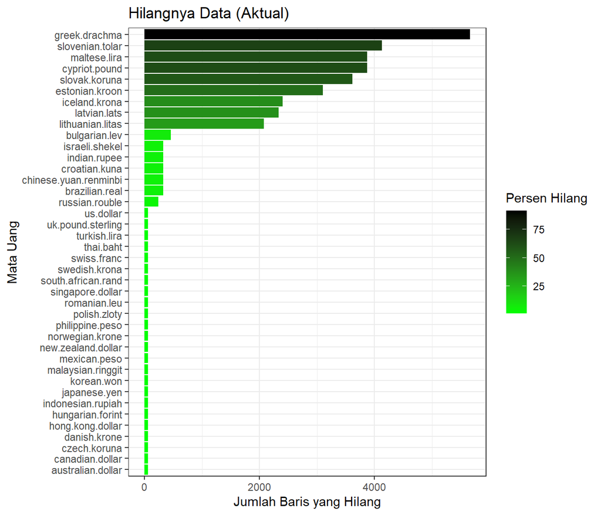

Banyaknya Baris yang Hilang (Aktual)

```r
missing_val_actual |>
  rownames_to_column("currency") |>
  ggplot(aes(x = fct_reorder(currency, missing_val_actual), y = missing_val_actual)) +
  geom_col(aes(fill = percentage_missing_actual)) +
  scale_fill_gradient(low = "green", high = "black") +
  theme_bw() +
  labs(
    title = "Hilangnya Data (Aktual)",
    x = "Mata Uang",
    y = "Jumlah Baris yang Hilang",
    fill = "Persen Hilang"
  ) +
  coord_flip()
```

Dari informasi diatas diambil kesimpulan untuk mengambil beberapa kolom saja yang memiliki kelengkapan data yang lebih baik. Dari eksplorasi diatas, diambil keputusan untuk mengambil kolom yang memiliki data yang hilang aktual kurang dari $100$. Kolom terpilih disimpan dalam variabel `selected_country`.

```r
selected_country <- missing_val_actual |>
  filter(missing_val_actual <= 100) |>
  rownames()
selected_country
```

```
##  [1] "australian.dollar"  "canadian.dollar"    "swiss.franc"
##  [4] "czech.koruna"       "danish.krone"       "uk.pound.sterling"
##  [7] "hong.kong.dollar"   "hungarian.forint"   "indonesian.rupiah"
## [10] "japanese.yen"       "korean.won"         "mexican.peso"
## [13] "malaysian.ringgit"  "norwegian.krone"    "new.zealand.dollar"
## [16] "philippine.peso"    "polish.zloty"       "romanian.leu"
## [19] "swedish.krona"      "singapore.dollar"   "thai.baht"
## [22] "turkish.lira"       "us.dollar"          "south.african.rand"
```

Kolom-kolom yang terpilih disimpan dalam bentuk objek baru bernama `exchange_r1_selected`. Berikut kilasan dataset.

```r
exchange_r1_selected <- exchange_r1_numeric |>
  select(all_of(selected_country))
exchange_r1_selected |> glimpse()
```

```
## Rows: 8,717
## Columns: 24
## $ australian.dollar  <dbl> 1.9100, 1.8944, 1.8820, 1.8474, 1.8406, NA, NA, 1.8…
## $ canadian.dollar    <dbl> 1.8004, 1.7965, 1.7711, 1.7602, 1.7643, NA, NA, 1.7…
## $ swiss.franc        <dbl> 1.6168, 1.6123, 1.6116, 1.6165, 1.6138, NA, NA, 1.6…
## $ czech.koruna       <dbl> 35.107, 34.917, 34.850, 34.886, 34.938, NA, NA, 35.…
## $ danish.krone       <dbl> 7.4501, 7.4495, 7.4452, 7.4431, 7.4433, NA, NA, 7.4…
## $ uk.pound.sterling  <dbl> 0.71110, 0.71220, 0.70760, 0.70585, 0.70940, NA, NA…
## $ hong.kong.dollar   <dbl> 9.1332, 9.1341, 9.1010, 9.0131, 9.0302, NA, NA, 8.9…
## $ hungarian.forint   <dbl> 251.48, 250.80, 250.67, 250.09, 250.15, NA, NA, 249…
## $ indonesian.rupiah  <dbl> 9433.61, 9314.51, 9337.68, 9218.77, 9321.63, NA, NA…
## $ japanese.yen       <dbl> 133.73, 130.96, 131.42, 129.43, 130.09, NA, NA, 126…
## $ korean.won         <dbl> 1398.59, 1373.01, 1359.54, 1337.16, 1366.73, NA, NA…
## $ mexican.peso       <dbl> 11.6446, 11.5960, 11.4705, 11.5511, 11.4414, NA, NA…
## $ malaysian.ringgit  <dbl> 4.4798, 4.4805, 4.4637, 4.4203, 4.4295, NA, NA, 4.3…
## $ norwegian.krone    <dbl> 8.8550, 8.7745, 8.7335, 8.6295, 8.5900, NA, NA, 8.5…
## $ new.zealand.dollar <dbl> 2.2229, 2.2011, 2.1890, 2.1531, 2.1557, NA, NA, 2.1…
## $ philippine.peso    <dbl> 45.510, 44.745, 44.872, 44.436, 44.295, NA, NA, 43.…
## $ polish.zloty       <dbl> 4.0712, 4.0245, 4.0065, 4.0165, 4.0363, NA, NA, 4.0…
## $ romanian.leu       <dbl> 1.3111, 1.3168, 1.3168, 1.3092, 1.3143, NA, NA, 1.2…
## $ swedish.krona      <dbl> 9.4696, 9.4025, 9.3050, 9.1800, 9.1650, NA, NA, 9.0…
## $ singapore.dollar   <dbl> 1.9554, 1.9655, 1.9699, 1.9436, 1.9537, NA, NA, 1.9…
## $ thai.baht          <dbl> 42.6799, 42.5048, 42.6949, 42.1678, 42.5590, NA, NA…
## $ turkish.lira       <dbl> 0.3723, 0.3728, 0.3722, 0.3701, 0.3718, NA, NA, 0.3…
## $ us.dollar          <dbl> 1.1789, 1.1790, 1.1743, 1.1632, 1.1659, NA, NA, 1.1…
## $ south.african.rand <dbl> 6.9358, 6.7975, 6.7307, 6.8283, 6.7855, NA, NA, 6.7…
```

Dari dataset tersebut bisa dilanjutkan ke pengisian data yang hilang.

### 3.3.2 Pengisian data yang hilang

Dataset `exchange_r1_selected` diperiksa nilai data yang hilangnya. Dari narasi diatas diketahui, hari Sabtu dan Minggu, memang tidak tersedia datanya. Sehingga, observasi tersebut harus diisi jika menginginkan dataset yang kontinyu dengan interval waktu dalam bentuk harian. Berikut baris yang hilang dan disimpan dalam bentuk `data.frame`. Dan berikut jumlah hari yang hilang setiap *weekday*.

```r
exchange_r1_missing <- exchange_r1_selected |>
  filter(exchange_r1_selected |> is.na() |> apply(1, all)) |>
  rownames_to_column("period.unit") |>
  mutate(
    period.unit = ymd(period.unit)
  )
date_missing <- exchange_r1_missing$period.unit
date_missing |> wday(label = TRUE, abbr = FALSE) |> table()
```

```
##
##    Sunday    Monday   Tuesday Wednesday  Thursday    Friday  Saturday
##      1245        36        15        13        12        36      1245
```

Data yang hilang akan diisi dengan metode `na.fill()` dengan menggunakan `fill = "extend"`. Data yang telah diisi disimpan pada objek `exchange_r1_fill`. Hal ini dipilih dikarenakan nilai mata uang bersifat kontinyu dari sebelum dan sesudahnya. Sehingga pengisian nilai harus diisi berdasarkan nilai terdekatnya.

```r
exchange_r1_fill <- exchange_r1_selected |>
  mutate_all(na.fill, fill = "extend")
exchange_r1_fill |> glimpse()
```

```
## Rows: 8,717
## Columns: 24
## $ australian.dollar  <dbl> 1.910000, 1.894400, 1.882000, 1.847400, 1.840600, 1…
## $ canadian.dollar    <dbl> 1.800400, 1.796500, 1.771100, 1.760200, 1.764300, 1…
## $ swiss.franc        <dbl> 1.616800, 1.612300, 1.611600, 1.616500, 1.613800, 1…
## $ czech.koruna       <dbl> 35.10700, 34.91700, 34.85000, 34.88600, 34.93800, 3…
## $ danish.krone       <dbl> 7.450100, 7.449500, 7.445200, 7.443100, 7.443300, 7…
## $ uk.pound.sterling  <dbl> 0.7111000, 0.7122000, 0.7076000, 0.7058500, 0.70940…
## $ hong.kong.dollar   <dbl> 9.133200, 9.134100, 9.101000, 9.013100, 9.030200, 9…
## $ hungarian.forint   <dbl> 251.4800, 250.8000, 250.6700, 250.0900, 250.1500, 2…
## $ indonesian.rupiah  <dbl> 9433.610, 9314.510, 9337.680, 9218.770, 9321.630, 9…
## $ japanese.yen       <dbl> 133.7300, 130.9600, 131.4200, 129.4300, 130.0900, 1…
## $ korean.won         <dbl> 1398.590, 1373.010, 1359.540, 1337.160, 1366.730, 1…
## $ mexican.peso       <dbl> 11.64460, 11.59600, 11.47050, 11.55110, 11.44140, 1…
## $ malaysian.ringgit  <dbl> 4.479800, 4.480500, 4.463700, 4.420300, 4.429500, 4…
## $ norwegian.krone    <dbl> 8.855000, 8.774500, 8.733500, 8.629500, 8.590000, 8…
## $ new.zealand.dollar <dbl> 2.222900, 2.201100, 2.189000, 2.153100, 2.155700, 2…
## $ philippine.peso    <dbl> 45.51000, 44.74500, 44.87200, 44.43600, 44.29500, 4…
## $ polish.zloty       <dbl> 4.071200, 4.024500, 4.006500, 4.016500, 4.036300, 4…
## $ romanian.leu       <dbl> 1.311100, 1.316800, 1.316800, 1.309200, 1.314300, 1…
## $ swedish.krona      <dbl> 9.469600, 9.402500, 9.305000, 9.180000, 9.165000, 9…
## $ singapore.dollar   <dbl> 1.955400, 1.965500, 1.969900, 1.943600, 1.953700, 1…
## $ thai.baht          <dbl> 42.67990, 42.50480, 42.69490, 42.16780, 42.55900, 4…
## $ turkish.lira       <dbl> 0.3723000, 0.3728000, 0.3722000, 0.3701000, 0.37180…
## $ us.dollar          <dbl> 1.178900, 1.179000, 1.174300, 1.163200, 1.165900, 1…
## $ south.african.rand <dbl> 6.935800, 6.797500, 6.730700, 6.828300, 6.785500, 6…
```

Dilakukan pengecekan ulang dengan `anyNA()`.

```r
anyNA(exchange_r1_fill)
```

```
## [1] FALSE
```

Menghasilkan `FALSE` yang artinya data sudah lengkap (tidak terdapat data yang kosong/hilang). Setelah ini dataset `exchange_r1_fill`, bisa dilanjutkan ke tahap **R2 - Eksplorasi Data**.

# 4 R2 - Eksplorasi Data

Setelah memastikan dataset sudah lengkap dan memenuhi kriteria kelengkapan data, dilanjutkan dengan mengeksplorasi dataset ini. Eksplorasi ini bisa berupa statistik deskriptif ataupun analisis terkait jenis data deret waktu (*time series*). Pada tahap ini dataset disimpan sebagai objek baru bernama `exchange_r2` yang merupakan objek `exchange_r1_fill`. Kolom `period.unit` dimunculkan kembali dari nama baris dan diubah sebagai jenis data waktu.

```r
exchange_r2 <- exchange_r1_fill |>
  rownames_to_column("period.unit") |>
  mutate(period.unit = ymd(period.unit))
exchange_r2 |> head()
```

|  | period.unit | australian.dollar | canadian.dollar | swiss.franc | czech.koruna | danish.krone | uk.pound.sterling | hong.kong.dollar | hungarian.forint | indonesian.rupiah | japanese.yen | korean.won | mexican.peso | malaysian.ringgit | norwegian.krone | new.zealand.dollar | philippine.peso | polish.zloty | romanian.leu | swedish.krona | singapore.dollar | thai.baht | turkish.lira | us.dollar | south.african.rand |
| --- | --- | --- | --- | --- | --- | --- | --- | --- | --- | --- | --- | --- | --- | --- | --- | --- | --- | --- | --- | --- | --- | --- | --- | --- | --- |
| 1 | 1999-01-04 | 1.910000 | 1.8004 | 1.616800 | 35.10700 | 7.4501 | 0.7111000 | 9.133200 | 251.48 | 9433.610 | 133.7300 | 1398.590 | 11.64460 | 4.479800 | 8.8550 | 2.2229 | 45.51000 | 4.071200 | 1.311100 | 9.469600 | 1.955400 | 42.67990 | 0.3723000 | 1.1789 | 6.935800 |
| 2 | 1999-01-05 | 1.894400 | 1.7965 | 1.612300 | 34.91700 | 7.4495 | 0.7122000 | 9.134100 | 250.80 | 9314.510 | 130.9600 | 1373.010 | 11.59600 | 4.480500 | 8.7745 | 2.2011 | 44.74500 | 4.024500 | 1.316800 | 9.402500 | 1.965500 | 42.50480 | 0.3728000 | 1.1790 | 6.797500 |
| 3 | 1999-01-06 | 1.882000 | 1.7711 | 1.611600 | 34.85000 | 7.4452 | 0.7076000 | 9.101000 | 250.67 | 9337.680 | 131.4200 | 1359.540 | 11.47050 | 4.463700 | 8.7335 | 2.1890 | 44.87200 | 4.006500 | 1.316800 | 9.305000 | 1.969900 | 42.69490 | 0.3722000 | 1.1743 | 6.730700 |
| 4 | 1999-01-07 | 1.847400 | 1.7602 | 1.616500 | 34.88600 | 7.4431 | 0.7058500 | 9.013100 | 250.09 | 9218.770 | 129.4300 | 1337.160 | 11.55110 | 4.420300 | 8.6295 | 2.1531 | 44.43600 | 4.016500 | 1.309200 | 9.180000 | 1.943600 | 42.16780 | 0.3701000 | 1.1632 | 6.828300 |
| 5 | 1999-01-08 | 1.840600 | 1.7643 | 1.613800 | 34.93800 | 7.4433 | 0.7094000 | 9.030200 | 250.15 | 9321.630 | 130.0900 | 1366.730 | 11.44140 | 4.429500 | 8.5900 | 2.1557 | 44.29500 | 4.036300 | 1.314300 | 9.165000 | 1.953700 | 42.55900 | 0.3718000 | 1.1659 | 6.785500 |
| 6 | 1999-01-09 | 1.831533 | 1.7583 | 1.612667 | 35.01633 | 7.4433 | 0.7077333 | 9.008633 | 250.00 | 9299.623 | 128.8367 | 1363.387 | 11.43833 | 4.418667 | 8.5795 | 2.1457 | 44.05167 | 4.034867 | 1.308867 | 9.142833 | 1.947733 | 42.35827 | 0.3720333 | 1.1629 | 6.787333 |

Langkah yang akan dilakukan dalam mengeksplorasi dataset dimulai dari deskripsi umum mengenai dataset, statistik dataset, kemudian diakhiri dengan eksplorasi sebagai data deret waktu.

## 4.1 Deskripsi dataset

Dataset yang digunakan adalah `exchange_r2`. Deskrpsi yang dimaksud adalah eksplorasi dini terkait jumlah observasi/baris, jumlah variabel/kolom, dan periode datasetnya. Berikut kilasan `exchange_r2`.

```r
exchange_r2 |> glimpse()
```

```
## Rows: 8,717
## Columns: 25
## $ period.unit        <date> 1999-01-04, 1999-01-05, 1999-01-06, 1999-01-07, 19…
## $ australian.dollar  <dbl> 1.910000, 1.894400, 1.882000, 1.847400, 1.840600, 1…
## $ canadian.dollar    <dbl> 1.800400, 1.796500, 1.771100, 1.760200, 1.764300, 1…
## $ swiss.franc        <dbl> 1.616800, 1.612300, 1.611600, 1.616500, 1.613800, 1…
## $ czech.koruna       <dbl> 35.10700, 34.91700, 34.85000, 34.88600, 34.93800, 3…
## $ danish.krone       <dbl> 7.450100, 7.449500, 7.445200, 7.443100, 7.443300, 7…
## $ uk.pound.sterling  <dbl> 0.7111000, 0.7122000, 0.7076000, 0.7058500, 0.70940…
## $ hong.kong.dollar   <dbl> 9.133200, 9.134100, 9.101000, 9.013100, 9.030200, 9…
## $ hungarian.forint   <dbl> 251.4800, 250.8000, 250.6700, 250.0900, 250.1500, 2…
## $ indonesian.rupiah  <dbl> 9433.610, 9314.510, 9337.680, 9218.770, 9321.630, 9…
## $ japanese.yen       <dbl> 133.7300, 130.9600, 131.4200, 129.4300, 130.0900, 1…
## $ korean.won         <dbl> 1398.590, 1373.010, 1359.540, 1337.160, 1366.730, 1…
## $ mexican.peso       <dbl> 11.64460, 11.59600, 11.47050, 11.55110, 11.44140, 1…
## $ malaysian.ringgit  <dbl> 4.479800, 4.480500, 4.463700, 4.420300, 4.429500, 4…
## $ norwegian.krone    <dbl> 8.855000, 8.774500, 8.733500, 8.629500, 8.590000, 8…
## $ new.zealand.dollar <dbl> 2.222900, 2.201100, 2.189000, 2.153100, 2.155700, 2…
## $ philippine.peso    <dbl> 45.51000, 44.74500, 44.87200, 44.43600, 44.29500, 4…
## $ polish.zloty       <dbl> 4.071200, 4.024500, 4.006500, 4.016500, 4.036300, 4…
## $ romanian.leu       <dbl> 1.311100, 1.316800, 1.316800, 1.309200, 1.314300, 1…
## $ swedish.krona      <dbl> 9.469600, 9.402500, 9.305000, 9.180000, 9.165000, 9…
## $ singapore.dollar   <dbl> 1.955400, 1.965500, 1.969900, 1.943600, 1.953700, 1…
## $ thai.baht          <dbl> 42.67990, 42.50480, 42.69490, 42.16780, 42.55900, 4…
## $ turkish.lira       <dbl> 0.3723000, 0.3728000, 0.3722000, 0.3701000, 0.37180…
## $ us.dollar          <dbl> 1.178900, 1.179000, 1.174300, 1.163200, 1.165900, 1…
## $ south.african.rand <dbl> 6.935800, 6.797500, 6.730700, 6.828300, 6.785500, 6…
```

```r
exchange_r2$period.unit |> summary() |> strftime("%d %B %Y")
```

```
##               Min.            1st Qu.             Median               Mean
##  "04 January 1999" "22 December 2004" "10 December 2010" "10 December 2010"
##            3rd Qu.               Max.
## "27 November 2016" "15 November 2022"
```

```r
exchange_r2 |> dim()
```

```
## [1] 8717   25
```

Dari informasi diatas diketahui bahwa `exchange_r2` memiliki $8,717$ baris dan $25$ kolom ($24$ mata uang dengan $1$ kolom waktu) yang dimulai dari $\text{4 Januari 1999}$ sampai $\text{15 November 2022}$. Pada tahap ini diambil keputusan untuk mengambil tiga mata uang saja untuk eksplorasi berikutnya sampai akhir. Mata uang yang digunakan antara lain `indonesian.rupiah`, `us.dollar`, `japanese.yen`. Kolom yang terpilih disimpan dalam objek `exchange_r2_selected`.

```r
exchange_r2_selected <- exchange_r2 |>
  select(period.unit, indonesian.rupiah, us.dollar, japanese.yen)
exchange_r2_selected |> glimpse()
```

```
## Rows: 8,717
## Columns: 4
## $ period.unit       <date> 1999-01-04, 1999-01-05, 1999-01-06, 1999-01-07, 199…
## $ indonesian.rupiah <dbl> 9433.610, 9314.510, 9337.680, 9218.770, 9321.630, 92…
## $ us.dollar         <dbl> 1.178900, 1.179000, 1.174300, 1.163200, 1.165900, 1.…
## $ japanese.yen      <dbl> 133.7300, 130.9600, 131.4200, 129.4300, 130.0900, 12…
```

Mata uang yang terpilih disimpan dalam variabel `r2_selected`.

```r
r2_selected <- exchange_r2_selected |>
  select(-period.unit) |>
  colnames()
```

## 4.2 Statistik Deskriptif

Untuk tahap ini dan seterusnya akan menggunakan dataset `exchange_r2_selected`. Berikut `summary()` dari dataset.

```r
exchange_r2_selected |>
  select(-period.unit) |>
  summary()
```

```
##  indonesian.rupiah   us.dollar       japanese.yen
##  Min.   : 6708     Min.   :0.8252   Min.   : 89.3
##  1st Qu.:11279     1st Qu.:1.0951   1st Qu.:117.1
##  Median :12864     Median :1.1891   Median :128.7
##  Mean   :12986     Mean   :1.1936   Mean   :127.6
##  3rd Qu.:15412     3rd Qu.:1.3123   3rd Qu.:135.8
##  Max.   :18240     Max.   :1.5990   Max.   :169.8
```

Dari informasi diatas diketahui nilai minimum, kuartil pertama/ketiga, median, rata-rata, dan maksimum. Nilai tiap kolom terlihat memiliki rentang (*range*) yang berbeda-beda. Sehingga jika dicoba untuk di plot distribusinya menggunakan `boxplot` akan berbeda.

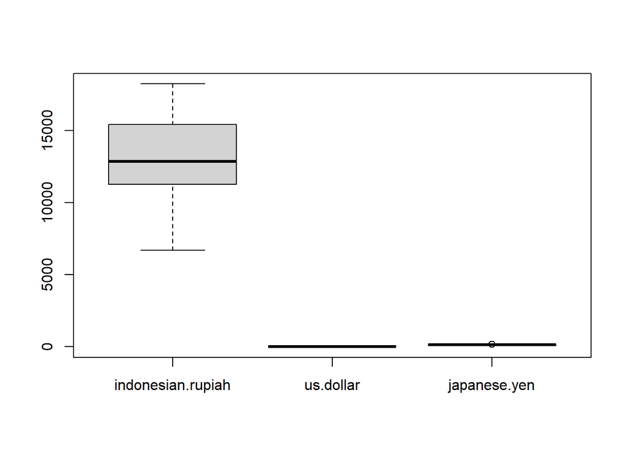

Boxplot Nilai Tukar

```r
exchange_r2_selected |>
  select(-period.unit) |>
  boxplot()
```

Salah satu cara untuk melihat perbandingan antar kolom dengan dilakukan normalisasi. Normalisasi yang digunakan adalah menggunakan minimum dan maksimumnya (minmax scale). Berikut boxplot yang serupa setelah normalisasi.

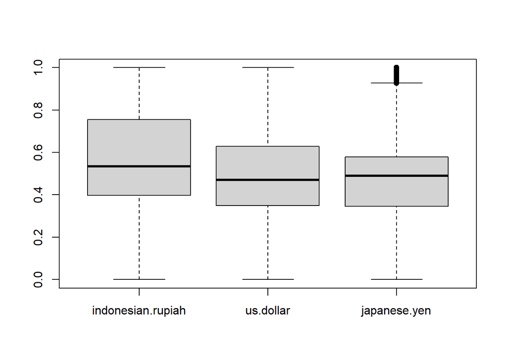

Boxplot Nilai Tukar (normalisasi)

```r
exchange_r2_minmax <- exchange_r2_selected |>
  mutate_if(
    is.numeric,
    function(.) {
      minvec <- min(.)
      maxvec <- max(.)
      normalize <- (. - minvec) / (maxvec - minvec)
    }
  )
exchange_r2_minmax |>
  select(-period.unit) |>
  boxplot()
```

Dari *boxplot* diatas, semua mata uang bisa dilihat distribusinya secara sekaligus. Mata uang `japanese.yen` memiliki beberapa potensi *outlier*. Sedangkan untuk `indonesia.rupiah` dan `us.dollar` tidak memilikinya. Hal tersebut bisa diinterpretasikan, bahwa pada `indonesian.rupiah` maupun `us.dollar` tidak ada lonjakan tajam yang diluar dari rata-rata maupun kuartilnya. Sedangkan untuk `japanese.yen` diduga terdapat posisi dimana mata uangnya yang berbeda dari seluruh observasi data lainnya.

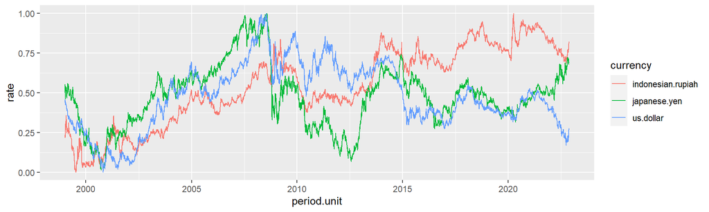

Perubahan Nilai Tukar Harian (Normalisasi)

```r
exchange_r2_minmax |>
  pivot_longer(cols = -period.unit, names_to = "currency", values_to = "rate") |>
  arrange(currency) |>
  ggplot(aes(x = period.unit, y = rate, color = currency)) +
  geom_line()
```

## 4.3 Eksplorasi *Time Series*

Untuk eksplorasi data deret waktu, yang digunakan hanyalah mata uang `indonesian.rupiah`.

```r
exchange_r2_rupiah <- exchange_r2_selected |>
  select(period.unit, indonesian.rupiah)
exchange_r2_rupiah |> glimpse()
```

```
## Rows: 8,717
## Columns: 2
## $ period.unit       <date> 1999-01-04, 1999-01-05, 1999-01-06, 1999-01-07, 199…
## $ indonesian.rupiah <dbl> 9433.610, 9314.510, 9337.680, 9218.770, 9321.630, 92…
```

Untuk eksplorasi berdasarkan jenis datanya, dibuat objek `ts_rupiah` yang mengubah objek `exchange_r2_rupiah` menjadi *time series* menggunakan `ts()`.

```r
ts_rupiah <- ts(exchange_r2_rupiah$indonesian.rupiah, start = c(1999, 1), frequency = 365)
```

Selanjutnya dilakukan *decomposition* untuk melihat karakteristik dataset `ts_rupiah`.

### 4.3.1 Dekomposisi

Dekomposisi dilakukan menggunakan fungsi `decompose()` yang membagi dataset menjadi tiga bagian utama yaitu *trend*, *seasonal*, dan *error* / *remainder*. Berikut objek dekomposisi `decompose_rupiah` beserta struktur datanya.

```r
decompose_rupiah <- ts_rupiah |> decompose()
decompose_rupiah |> str()
```

```
## List of 6
##  $ x       : Time-Series [1:8717] from 1999 to 2023: 9434 9315 9338 9219 9322 ...
##  $ seasonal: Time-Series [1:8717] from 1999 to 2023: 173 175 181 141 94 ...
##  $ trend   : Time-Series [1:8717] from 1999 to 2023: NA NA NA NA NA NA NA NA NA NA ...
##  $ random  : Time-Series [1:8717] from 1999 to 2023: NA NA NA NA NA NA NA NA NA NA ...
##  $ figure  : num [1:365] 173 175 181 141 94 ...
##  $ type    : chr "additive"
##  - attr(*, "class")= chr "decomposed.ts"
```

Didapatkan tiga komponen dekomposisi yaitu `seasonal`, `trend`, dan `random`. Dan secara *default* dataset termasuk *additive time series*. Berikut grafik dekomposisi menggunakan `autoplot()`.

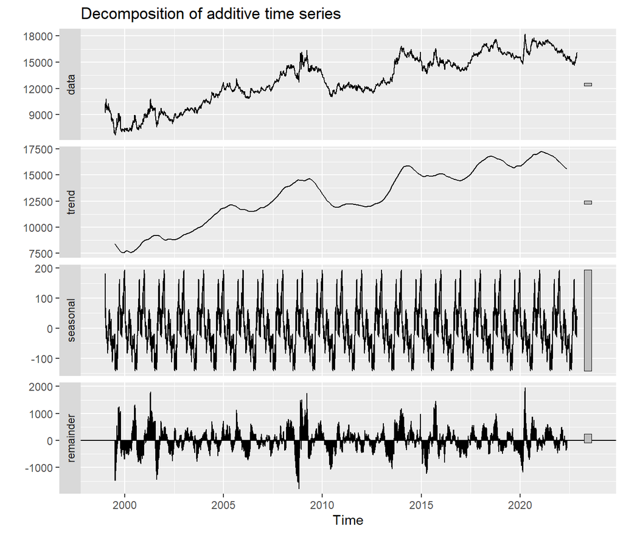

Dekomposisi Nilai Tukar Rupiah

```r
decompose_rupiah |> autoplot()
```

Dari grafik dekomposisi diatas, terlihat bahwa hasil `decompose()` mengeluarkan tiga komponen utamanya. Akan tetapi, hasil diatas belum tentu sesuai dengan kenyataannya. Dan harus dieksplorasi lebih lanjut.

# 5 R3 - Pemodelan

Untuk pemodelan digunakan Holt Winters dan ARIMA. dataset yang digunakan adalah `ts_rupiah`. Tapi sebelumnya dataset harus dibagi menjadi dua bagian yaitu train set dan testing set.

```r
window_selected <- 365
train_ts <- ts_rupiah |> head(-window_selected)
test_ts <- ts_rupiah |> tail(window_selected)
```

Pemodelan Holt Winters dan ARIMA menggunakan `holtwinter` dan `stlm`.

```r
hw_rupiah <- HoltWinters(train_ts)
arima_rupiah <- stlm(train_ts, s.window = 365, method = "arima")
```

# 6 R4 - Evaluasi

Evaluasi

```r
hw_forecast <- forecast(hw_rupiah, window_selected)
arima_forecast <- forecast(arima_rupiah, window_selected)
```

```r
accuracy(hw_forecast, test_ts)
```

```
##                       ME     RMSE      MAE         MPE      MAPE      MASE
## Training set    3.164765 121.6350  80.6686  0.02337438 0.6513953 0.0688837
## Test set     -516.177619 910.2031 650.2115 -3.42822365 4.2676716 0.5552219
##                   ACF1 Theil's U
## Training set 0.5521309        NA
## Test set     0.9906554  14.43078
```

```r
accuracy(arima_forecast, test_ts)
```

```
##                        ME      RMSE       MAE          MPE      MAPE       MASE
## Training set    0.7814501  75.46314  48.48109  0.004273649 0.4012051 0.04139847
## Test set     -594.6595784 762.99467 624.46642 -3.911100785 4.0932986 0.53323790
##                       ACF1 Theil's U
## Training set -0.0001222072        NA
## Test set      0.9865063092   12.0606
```

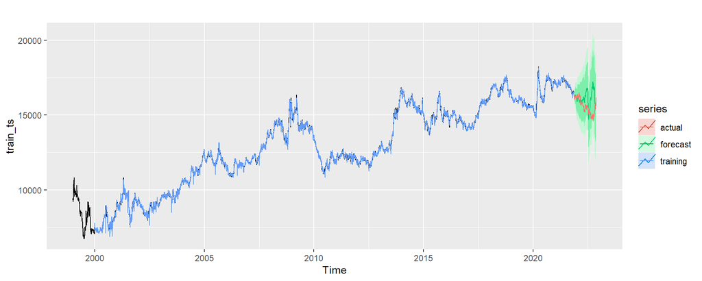

Training dan Prediksi menggunakan Holt-Winters

```r
train_ts |>
  autoplot() +
  autolayer(hw_rupiah$fitted[,'xhat'], series = "training") +
  autolayer(hw_forecast, series = "forecast") +
  autolayer(test_ts, series = "actual")
```

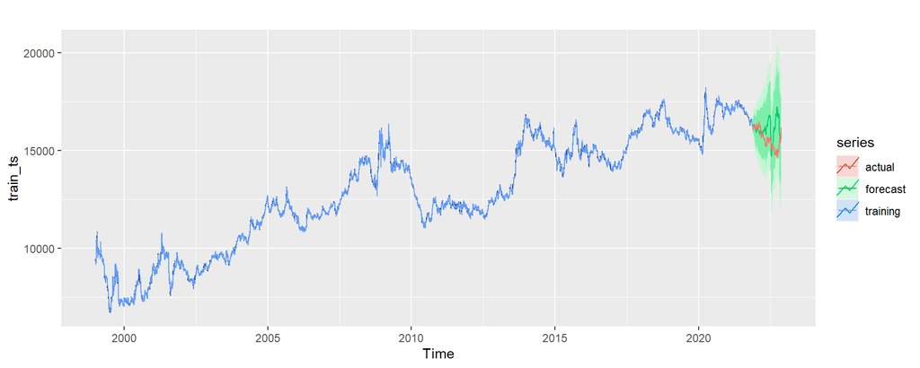

```r
train_ts |>
  autoplot() +
  autolayer(arima_rupiah$fitted, series = "training") +
  autolayer(hw_forecast, series = "forecast") +
  autolayer(test_ts, series = "actual")
```

# 7 Penutup

## 7.1 Kesimpulan

## 7.2 Saran

Berikut saran yang bisa diberikan:

- Pada tahapan mengubah tipe data kolom, bisa dievaluasi setiap kolomnya atau kolom tertentu (tergantung kebutuhan bisnisnya). Sehinggga fokus eksplorasi data sudah ditentukan sejak awal yaitu sebelum masuk ke pra-pemrosesan data.
- Di investigasi akhir *coercion*, dinyatakan bahwa “seluruh isiannya merupakan angka”. Hal tersebut bisa keliru jika terdapat isian yang merupakan angka tapi tidak *valid*. Semisal, nilai “1.23121312.3” akan dideteksi `TRUE` karena memiliki komponen `:digit:`, meski jika dilakukan `as.numeric()` akan muncul peringatan dan menghasilkan nilai `NA`. Hal tersebut dikarenakan penggunaan `str_detect()` dengan `pattern = "[:digit:]"`.
- Konsistensi penamaan dengan `class` objek. Dalam lembar kerja, objek `missing_val` merupakan `list`, sedangkan `missing_val_actual` merupakan `data.frame`. Untuk konsistensi dan memudahkan *troubleshooting*, sebaiknya dilakukan penamaan dan konsistensi tipe objeknya.